# ContextBase Predictive Analytics

Authored by John Akwei, ECMp ERMp Data Scientist

June 11, 2016

## This document contains examples of the Predictive Analytics capabilities of ContextBase, http://contextbase.github.io.

## Predictive Analytics Example 1: Linear Regression

Linear Regression allows for prediction of future occurrences derived from one explanatory variable, and one response variable.

```r
library(knitr)
revenue <- freeny.x
kable(head(revenue))
```

| lag quarterly revenue | price index | income level | market potential |
| --- | --- | --- | --- |
| 8.79636 | 4.70997 | 5.82110 | 12.9699 |
| 8.79236 | 4.70217 | 5.82558 | 12.9733 |
| 8.79137 | 4.68944 | 5.83112 | 12.9774 |
| 8.81486 | 4.68558 | 5.84046 | 12.9806 |
| 8.81301 | 4.64019 | 5.85036 | 12.9831 |
| 8.90751 | 4.62553 | 5.86464 | 12.9854 |

```r
colnames(revenue) <- c("lag_quarterly_revenue", "price_index",
                       "income_level", "market_potential")
revenue <- data.frame(revenue)
model <- lm(market_potential~price_index, revenue)

cat("The Intercept =", model$coefficients[1])
```

```
## The Intercept = 15.21788
```

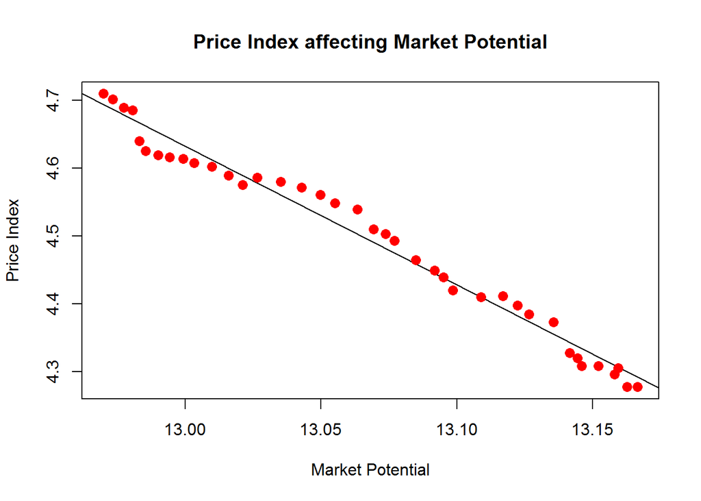

```r
test <- data.frame(price_index=4.57592)
result <- predict(model, test)

plot(revenue$market_potential, revenue$price_index, col = "red",
     main = "Price Index affecting Market Potential",
     abline(lm(revenue$price_index~revenue$market_potential)),
     cex = 1.3, pch = 16, xlab = "Market Potential",
     ylab = "Price Index")
```

## Example 1 - Linear Regression Conclusion:

```r
cat("For a Price Index of ", as.character(test), ", the predicted Market Potential = ", round(result, 2), ".", sep="")
```

```
## For a Price Index of 4.57592, the predicted Market Potential = 13.03.
```

## Predictive Analytics Example 2: Logistic Regression

Logistic Regression allows for prediction of a logical, (Yes or No), occurrence based on the effects of an explanatory variable on a response variable. For example, the probability of winning a congressional election vs campaign expenditures.

How does the amount of money spent on a campaign affect the probability that the candidate will win the election?

Source of Data Ranges: https://www.washingtonpost.com/news/the-fix/wp/2014/04/04/think-money-doesnt-matter-in-elections-this-chart-says-youre-wrong/

```r
Expenditures <- c(1000000, 1100000, 1200000, 1300000, 1400000,
                  1500000, 1600000, 1700000, 1800000, 1900000,
                  2000000, 2100000, 2200000, 2300000, 2400000,
                  2000000, 2100000, 2200000, 2300000, 2400000)
ElectionResult <- c(0, 0, 0, 0, 0, 0, 1, 0, 1, 0, 1, 0, 1, 0, 1,    1, 1, 1, 1, 1)

CampaignCosts <- data.frame(Expenditures, ElectionResult)

kable(CampaignCosts, caption = "Campaign Expenditures of Candidates vs Election Results")
```

Campaign Expenditures of Candidates vs Election Results

| Expenditures | ElectionResult |
| --- | --- |
| 1000000 | 0 |
| 1100000 | 0 |
| 1200000 | 0 |
| 1300000 | 0 |
| 1400000 | 0 |
| 1500000 | 0 |
| 1600000 | 1 |
| 1700000 | 0 |
| 1800000 | 1 |
| 1900000 | 0 |
| 2000000 | 1 |
| 2100000 | 0 |
| 2200000 | 1 |
| 2300000 | 0 |
| 2400000 | 1 |
| 2000000 | 1 |
| 2100000 | 1 |
| 2200000 | 1 |
| 2300000 | 1 |
| 2400000 | 1 |

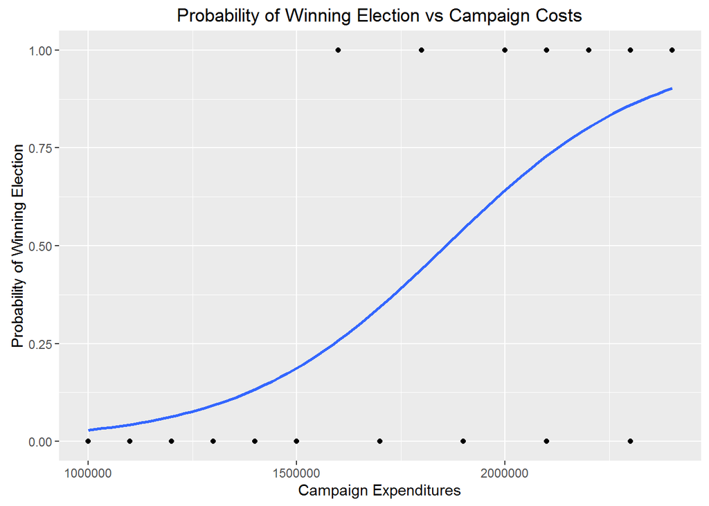

```r
library(ggplot2)
ggplot(CampaignCosts, aes(Expenditures, ElectionResult)) +
  geom_point(aes()) +
  geom_smooth(method='glm',
              method.args = list(family = "binomial"), se=FALSE) +
  labs (x="Campaign Expenditures", y="Probability of Winning Election", title="Probability of Winning Election vs Campaign Costs")
```

The logistic regression analysis gives the following output:

```r
model <- glm(ElectionResult ~., family=binomial(link='logit'), data=CampaignCosts)
model$coefficients
```

```
##   (Intercept)  Expenditures
## -7.615054e+00  4.098080e-06
```

Probability of winning election = 1/(1+exp(-(-7.615054e+00+4.098080e-06*CampaignExpenses)))

For a Candidate that has $1,600,000 in expenditures:

```r
CampaignExpenses <- 1600000
ProbabilityOfWinningElection <- 1/(1+exp(-(-7.615054e+00+4.098080e-06*CampaignExpenses)))

cat("Probability of winning Election = 1/(1+exp(-(-7.615054e+00+4.098080e-06*",
    CampaignExpenses, "))) = ", round(ProbabilityOfWinningElection, 2), ".", sep="")
```

```
## Probability of winning Election = 1/(1+exp(-(-7.615054e+00+4.098080e-06*1600000))) = 0.26.
```

For a Candidate that has $2,100,000 in expenditures:

```r
CampaignExpenses <- 2100000
ProbabilityOfWinningElection <- 1/(1+exp(-(-7.615054e+00+4.098080e-06*CampaignExpenses)))

cat("Probability of winning Election = 1/(1+exp(-(-7.615054e+00+4.098080e-06*",
    CampaignExpenses, "))) = ", round(ProbabilityOfWinningElection, 2), ".", sep="")
```

```
## Probability of winning Election = 1/(1+exp(-(-7.615054e+00+4.098080e-06*2100000))) = 0.73.
```

## Example 2 - Logistic Regression Conclusion:

```r
ElectionWinTable <- data.frame(column1=c(1100000, 1400000,
                                         1700000, 1900000,
                                         2300000),
                               column2=
      c(round(1/(1+exp(-(-7.615054e+00+4.098080e-06*1100000))), 2),
      round(1/(1+exp(-(-7.615054e+00+4.098080e-06*1400000))), 2),
      round(1/(1+exp(-(-7.615054e+00+4.098080e-06*1700000))), 2),
      round(1/(1+exp(-(-7.615054e+00+4.098080e-06*1900000))), 2),
      round(1/(1+exp(-(-7.615054e+00+4.098080e-06*2300000))), 2)))
names(ElectionWinTable) <- c("Campaign Expenses", "Probability of Winning Election")
kable(ElectionWinTable)
```

| Campaign Expenses | Probability of Winning Election |
| --- | --- |
| 1100000 | 0.04 |
| 1400000 | 0.13 |
| 1700000 | 0.34 |
| 1900000 | 0.54 |
| 2300000 | 0.86 |

### In conclusion to ContextBase Predictive Analytics Example 2, a direct correlation of Campaign Expenditures to Election Performance was verified. The above table displays corresponding probablities of winning an election to campaign expenses.

## Predictive Analytics Example 3: Multiple Regression

Multiple Regression allows for the prediction of the future values of a response variable, based on values of multiple explanatory variables.

```r
input <- data.frame(state.x77[,1:4])
kable(head(input))
```

|  | Population | Income | Illiteracy | Life.Exp |
| --- | --- | --- | --- | --- |
| Alabama | 3615 | 3624 | 2.1 | 69.05 |
| Alaska | 365 | 6315 | 1.5 | 69.31 |
| Arizona | 2212 | 4530 | 1.8 | 70.55 |
| Arkansas | 2110 | 3378 | 1.9 | 70.66 |
| California | 21198 | 5114 | 1.1 | 71.71 |
| Colorado | 2541 | 4884 | 0.7 | 72.06 |

```r
colnames(input) <- c("Population", "Income", "Illiteracy", "Life_Exp")

# Create the relationship model.
model <- lm(Life_Exp~Population+Income+Illiteracy, data=input)

# Show the model.
print(model)
```

```
##
## Call:
## lm(formula = Life_Exp ~ Population + Income + Illiteracy, data = input)
##
## Coefficients:
## (Intercept)   Population       Income   Illiteracy
##   7.120e+01   -1.024e-05    2.477e-04   -1.179e+00
```

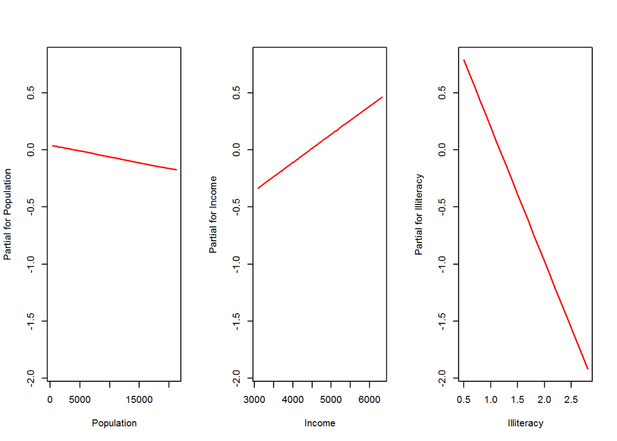

```r
# Multiple Regression Plot
par(mfrow=c(1,3))
termplot(model)
```

```r
a <- coef(model)[1]
cat("The Multiple Regression Intercept = ", a, ".", sep="")
```

```
## The Multiple Regression Intercept = 71.2023.
```

```r
XPopulation <- coef(model)[2]
XIncome <- coef(model)[3]
XIlliteracy <- coef(model)[4]

modelCoef <- data.frame(XPopulation, XIncome, XIlliteracy)
colnames(modelCoef) <- c("Population", "Income", "Illiteracy")
row.names(modelCoef) <- c("Coefficients")
kable(modelCoef)
```

|  | Population | Income | Illiteracy |
| --- | --- | --- | --- |
| Coefficients | -1.02e-05 | 0.0002477 | -1.178788 |

## Multiple Regression Conclusion:

```r
popl <- 3100
Incm <- 5348
Illt <- 1.1

Y = a + popl * XPopulation + Incm * XIncome + Illt * XIlliteracy
cat("For a City where Population = ", popl, ", Income = ", Incm,  ", and Illiteracy = ", Illt, ",
the predicted Life Expectancy is: ", round(Y, 2), ".", sep="")
```

```
## For a City where Population = 3100, Income = 5348, and Illiteracy = 1.1,
## the predicted Life Expectancy is: 71.2.
```

### In conclusion to ContextBase Predictive Analytics Example 3, the multiple variables of “Population”, “Income”, and “Illiteracy” were used to determine the predicted “Life Expectancy” of an area corresponding to a USA State. For an area with a Population of 3100, a per capita Income Rate of 5348, and an Illiteracy Rate of 1.1, a Life Expectancy of 71.2 years was predicted.